# Trabalho Computacional 4

EST077 - 2025.1

Autor

Milena Paz Freitas

# Relação entre horas de estudo e desempenho em uma avaliação

Uma escola está interessada em entender a relação entre o número de horas de estudo e o desempenho dos alunos em uma prova padronizada. Para isso, coletou dados de 15 estudantes, registrando o total de horas que cada um estudou na semana anterior ao exame e a respectiva pontuação obtida.

Importando os dados:

**Mostrar/esconder código**

```r
df <- data.frame(
hours = c(1, 2, 4, 5, 5, 6, 6, 7, 8, 10, 11, 11, 12, 12, 14),
score = c(64, 66, 76, 73, 74, 81, 83, 82, 80, 88, 84, 82, 91, 93, 89)
)
```

### Representação gráfica e ajuste de um modelo de regressão

**Mostrar/esconder código**

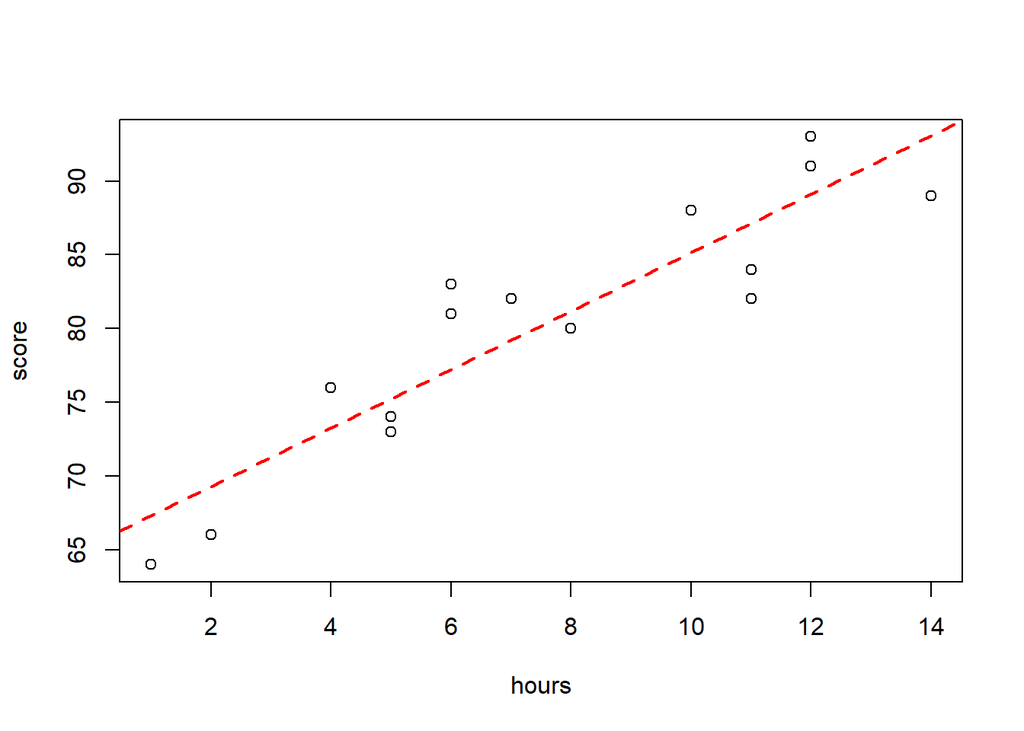

```r
plot(score~hours,data=df)
#ajuste por mínimos quadrados
ml <- lm(score~hours,data=df)
#intercepto e coef angular:
ab <- ml$coefficients
names(ab) <- NULL
#adiciona ajuste no plot
abline(ml,lty=2,col="red",lwd=2)
```

Deseja-se usar o modelo para prever o desempenho de um aluno que estudou 19 horas. Assim:

**Mostrar/esconder código**

```r
ab[2]*19 + ab[1]
```

```
[1] 102.9991
```

é a pontuação esperada de um aluno que estudou por 19h. Se a prova valer 100 pontos, por exemplo, é esperado que esse aluno obtenha pontuação alta ou máxima.

### Avaliação do modelo

A qualidade do ajuste pode ser avaliada por meio do coeficiente de determinação $R^2$, que quanto mais próximo de 1 melhor a capacidade de predição do ajuste (menor erro). Temos que:

**Mostrar/esconder código**

```r
#R2
summary(ml)$r.squared
```

```
[1] 0.8309798
```

é o valor de $R^2$, indicando boa representatividade dos dados pelo ajuste. Além disso, é interessante avaliar os resíduos do modelo linear:

**Mostrar/esconder código**

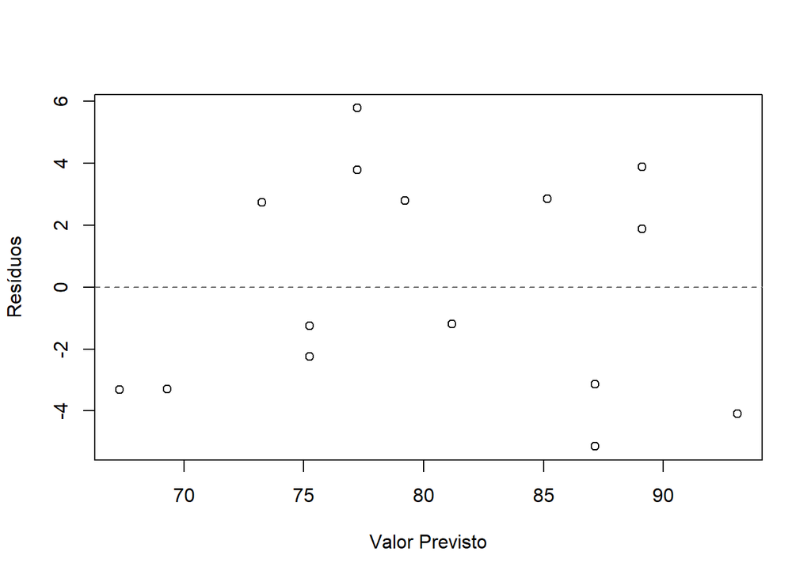

```r
#visualmente:
plot(ab[2]*df$hours + ab[1],ml$residuals,xlab="Valor Previsto",ylab="Resíduos")
abline(h=0,lty=2,col="grey40")
```

Podemos observar que eles estão dispersos de forma aleatória, mais um indicador de que este é um bom ajuste.

## Conclusão

A natureza da relação entre o tempo de estudo e pontuação no teste é de correlação e não causação. Ou seja, por conta do modelo estar bem ajustado, podemos concluir que maiores tempos de estudo estão correlacionados com bom desempenho, mas não que este seja consequência do tempo de estudo.